# Benchmarking: cell type annotation

# 1. The reference

The reference is BoneMarrowMap (Zeng et al.), a Symphony reference built on normal human bone marrow. It ships as a 345 MB reference object plus a 221 MB uwot model, both downloaded once into `annotation/`. Projection is `map_Query()` -> `calculate_MappingError()` -> `predict_CellTypes()` -> `predict_Pseudotime()`, with the demultiplexed sample as the batch variable so Symphony harmonises across donors within a pool rather than treating the GEM well as one batch.

**`00a_BoneMarrowMap_reference_broad_celltype.pdf`**

The reference itself, coloured by broad cell type in the project palette. Query cells are placed into this space; they do not move it. Stromal is the grey island - it is in the reference, and it is the population that used to be dropped from every figure by the palette bug described in section 9.

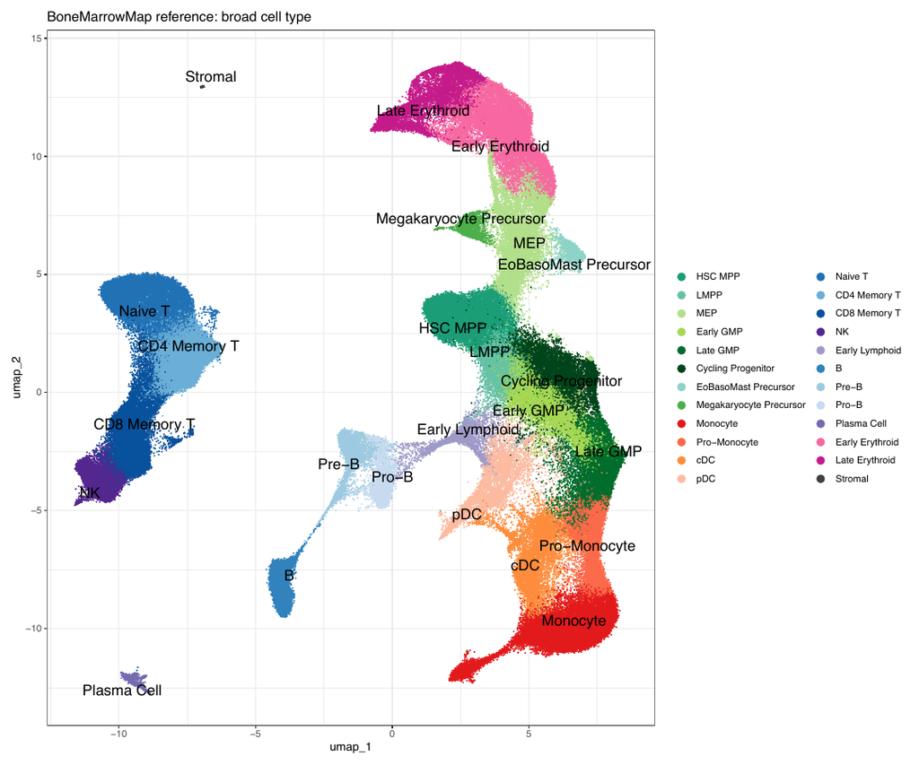

The reference returns two label columns, and the difference between them is the single thing most likely to cause trouble downstream:

How the fine labels roll up into the broad ones (10 broadest, LK1 + LK2 pooled)

[output not shown]

# 2. How many cells the reference refuses

`calculate_MappingError()` scores each cell on how well it sits in reference space and calls anything beyond `MAD_threshold` median absolute deviations a Fail. Failed cells keep their projected coordinates but lose their label.

Mapping-error QC, whole run (MAD_threshold = 2.5)

| run | mapping_error_QC | n | total | percent |
| --- | --- | --- | --- | --- |
| LK1 pilot | Fail | 1713 | 21541 | 7.95 |
| LK1 pilot | Pass | 19828 | 21541 | 92.05 |
| LK2 | Fail | 1195 | 21800 | 5.48 |
| LK2 | Pass | 20605 | 21800 | 94.52 |

Rejection rate per demultiplexed sample, worst first

| run | sample | mapping_error_QC | n | total | percent |
| --- | --- | --- | --- | --- | --- |
| LK2 | APOP576-TP53 | Fail | 543 | 1812 | 29.97 |
| LK1 pilot | HBDN501-AML-KMT2A | Fail | 351 | 3154 | 11.13 |
| LK1 pilot | MOLM13 | Fail | 656 | 6262 | 10.48 |
| LK1 pilot | HBDN392-AML-MDS | Fail | 422 | 6144 | 6.87 |
| LK1 pilot | HBDN206-MNpCT | Fail | 284 | 5981 | 4.75 |
| LK2 | normal-01 | Fail | 146 | 3568 | 4.09 |
| LK2 | HBDN376-TP53 | Fail | 287 | 9053 | 3.17 |
| LK2 | HBDN498-TP53 | Fail | 219 | 7367 | 2.97 |

**`01_mapping_QC_fail_by_sample.pdf`**

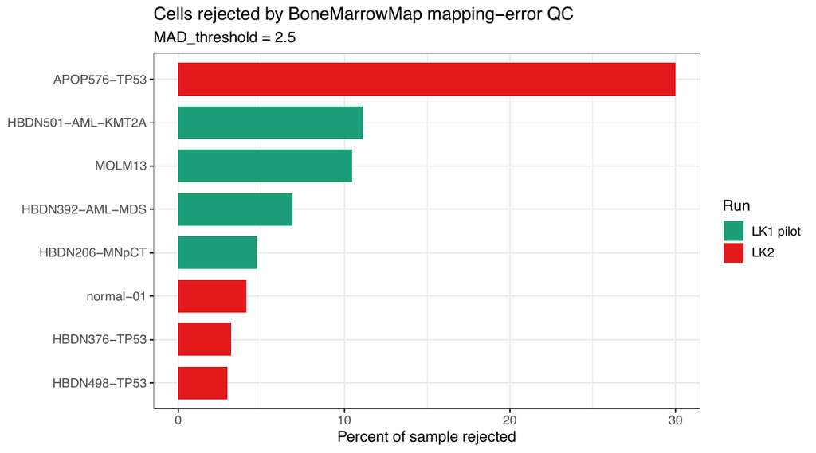

**`01_mapping_error_QC.pdf`**

The mapping error distribution and the threshold, pilot run.

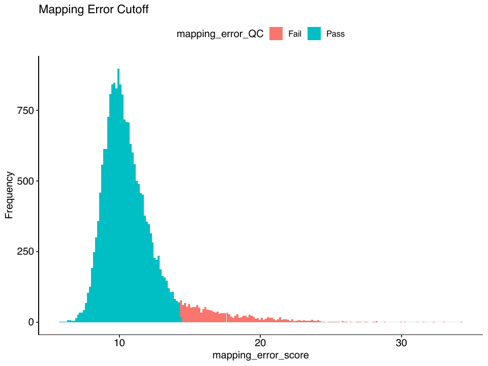

**`01_mapping_error_QC.pdf`**

The same for LK2.

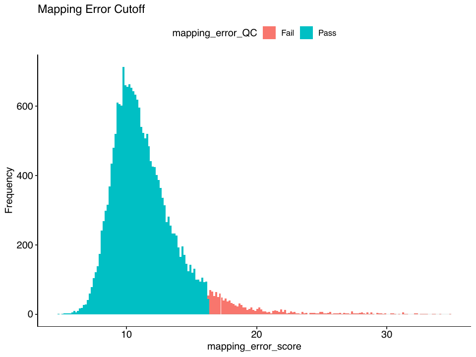

The ordering is the point. A reference built on normal marrow places normal cells well and leukaemic cells less well, so the rejection rate reads as distance from normal rather than as a technical failure. It is worth checking whenever a new sample comes in.

# 3. What the refused cells are

Median QC covariates, cells that pass versus cells that fail

| run | mapping_error_QC | n | nCount_RNA | nFeature_RNA | percent.mt | percent.ribo | scDblFinder.score | mapping_error_score |
| --- | --- | --- | --- | --- | --- | --- | --- | --- |
| LK1 pilot | Fail | 1713 | 2300 | 1370 | 5.092 | 4.970 | 0.390 | 16.657 |
| LK1 pilot | Pass | 19828 | 4272 | 2076 | 2.646 | 21.424 | 0.394 | 10.199 |
| LK2 | Fail | 1195 | 1380 | 837 | 3.910 | 4.657 | 0.063 | 18.081 |
| LK2 | Pass | 20605 | 6005 | 2556 | 2.776 | 18.804 | 0.150 | 10.767 |

**`02_rejected_cell_profile.pdf`**

The rejected cells are shallower, more mitochondrial and much less ribosomal than the cells that pass. The ribosomal drop is the clearest separator - roughly a four-fold difference in both runs.

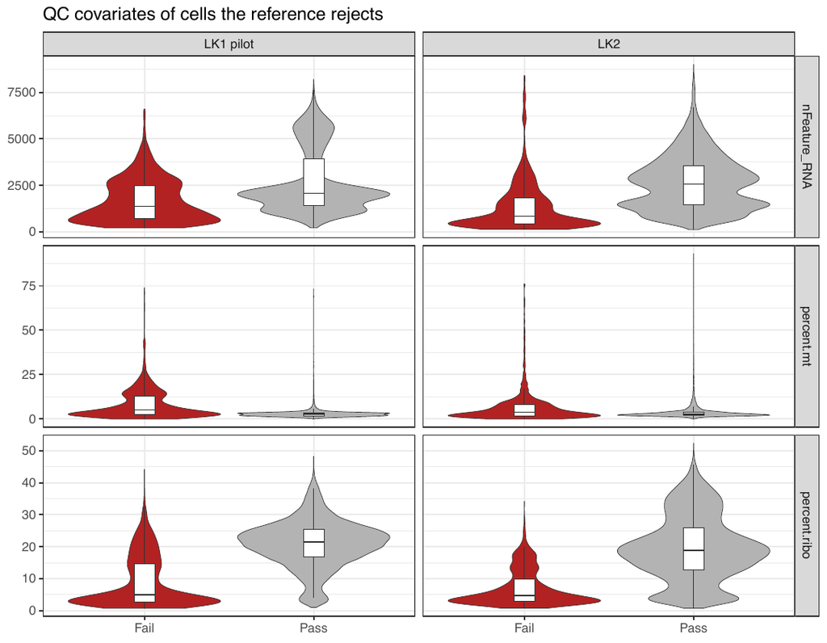

Step 03 pushes this further on the LK2 pipeline checkpoint, where the same projection is run at `MAD_threshold = 4` and the failed cells are followed individually.

Unknown versus annotated cells, median QC covariates (MAD_threshold = 4)

| is_unknown | n | nCount_RNA | nFeature_RNA | percent.mt | percent.ribo | scDblFinder.score |
| --- | --- | --- | --- | --- | --- | --- |
| FALSE | 25351 | 6211.0 | 2578.0 | 2.762967 | 19.757907 | 0.0003023 |
| TRUE | 346 | 772.5 | 511.5 | 3.225688 | 6.270695 | 0.0000054 |

Unknown fraction by donor

| sample_name | is_unknown | n | percent |
| --- | --- | --- | --- |
| APOP576-TP53 | TRUE | 182 | 7.9372002 |
| normal-01 | TRUE | 68 | 1.7046879 |
| HBDN376-TP53 | TRUE | 63 | 0.6673729 |
| HBDN498-TP53 | TRUE | 33 | 0.3308271 |

HTO classification of Unknown versus annotated cells

| is_unknown | HTO_classification.global | n | percent |
| --- | --- | --- | --- |
| FALSE | Doublet | 2946 | 11.620843 |
| FALSE | Negative | 2503 | 9.873378 |
| FALSE | Singlet | 19902 | 78.505779 |
| TRUE | Doublet | 53 | 15.317919 |
| TRUE | Negative | 74 | 21.387283 |
| TRUE | Singlet | 219 | 63.294798 |

Unknown cells are enriched in HTO-negative droplets (21.4% against 9.9%), which is the same population that fails hashing - low-content droplets that carry neither enough transcriptome to place nor enough hashtag to assign.

**`01_unknown_fraction_by_cluster.pdf`**

Unknown cells are not spread evenly: one native cluster (11) is a fifth Unknown, the rest are under 3%. They form a compartment, not a background.

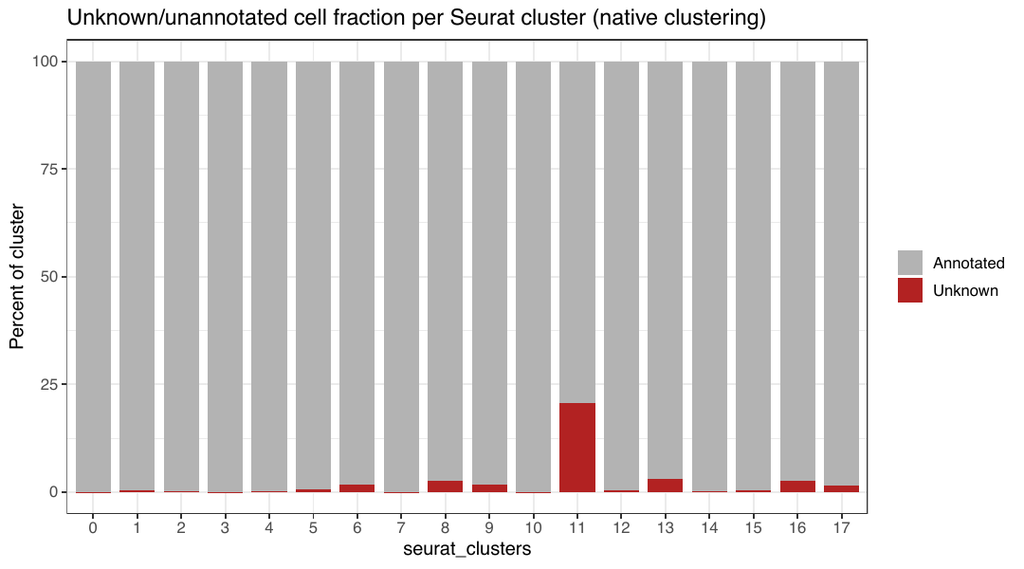

**`02_umap_native_with_unknown.pdf`**

Native UMAP with Unknown as its own category.

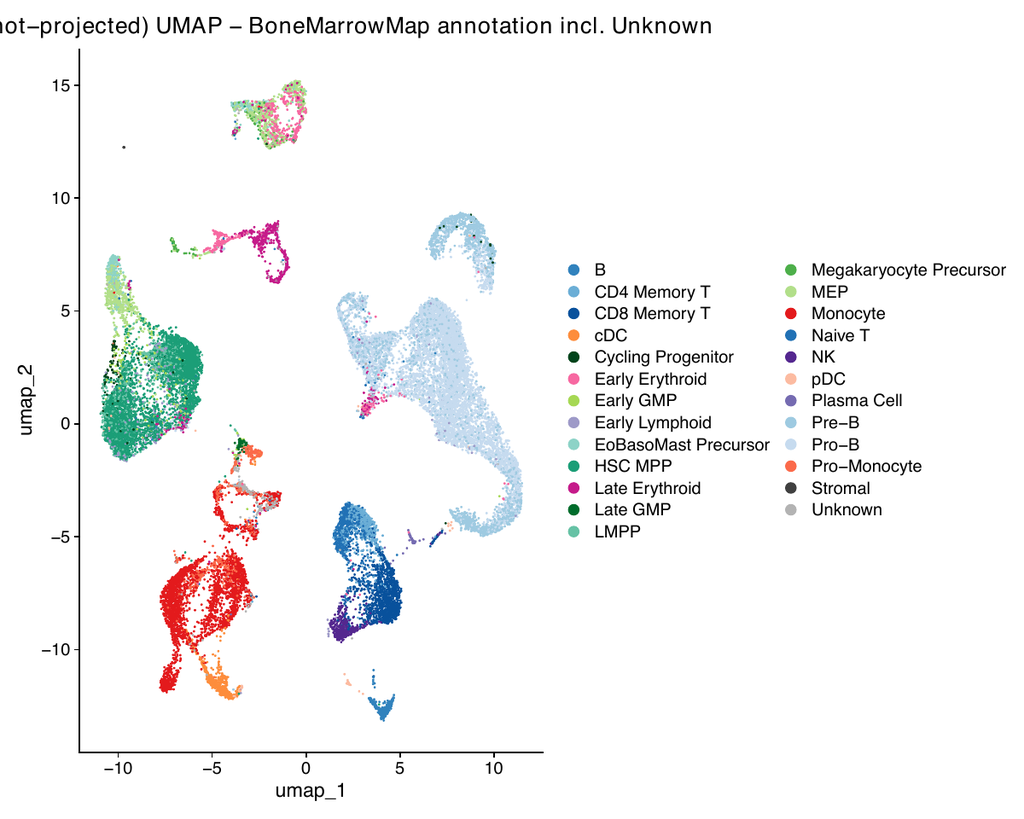

**`02a_umap_native_unknown_highlighted.pdf`**

The same, with only the Unknown cells picked out - they sit together rather than scattering across the manifold.

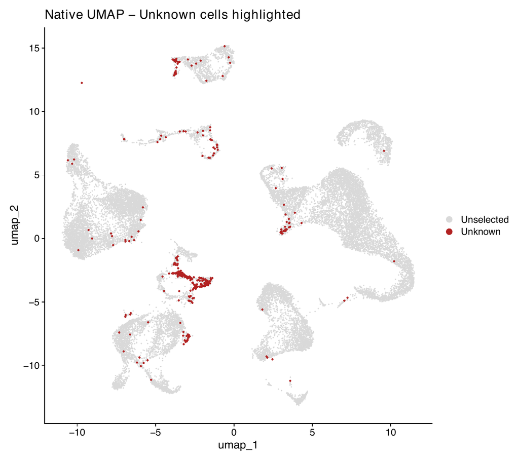

**`03_umap_projected_with_unknown.pdf`**

The reference-projected UMAP, same colouring.

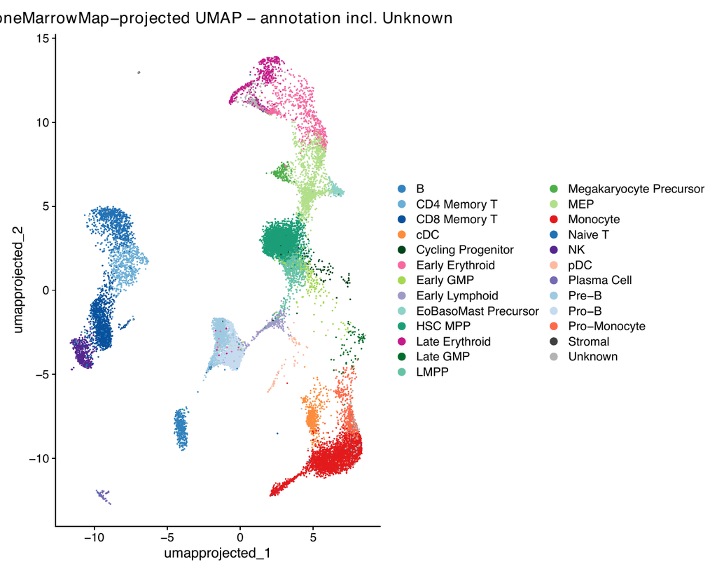

**`03a_umap_projected_unknown_highlighted.pdf`**

Unknown cells on the projected UMAP.

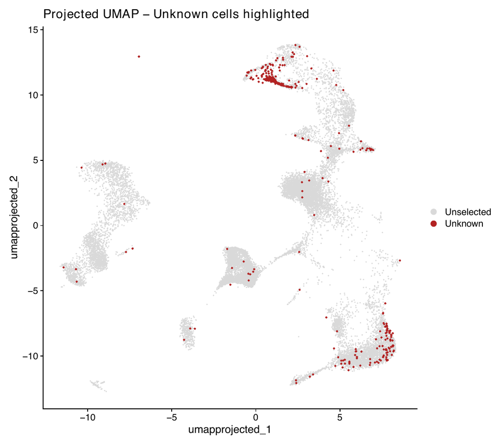

**`04_unknown_nearest_neighbor_identity_umap_projected.pdf`**

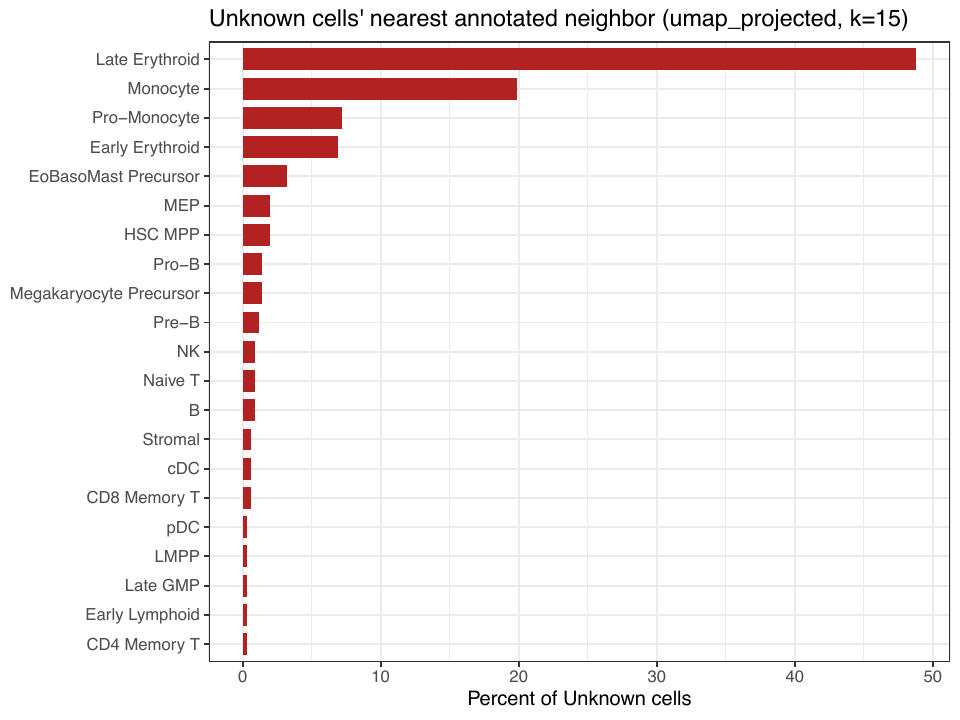

**`04_unknown_nearest_neighbor_identity_umap.pdf`**

If each Unknown cell is forced to take the majority label of its 15 nearest annotated neighbours in the object’s own embedding, they come out mostly monocyte and pro-monocyte.

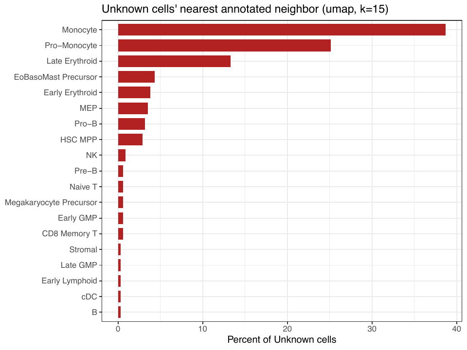

Nearest annotated neighbour, native embedding

| nearest_known_celltype | n | percent |
| --- | --- | --- |
| Monocyte | 134 | 38.7 |
| Pro-Monocyte | 87 | 25.1 |
| Late Erythroid | 46 | 13.3 |
| EoBasoMast Precursor | 15 | 4.3 |
| Early Erythroid | 13 | 3.8 |
| MEP | 12 | 3.5 |
| Pro-B | 11 | 3.2 |
| HSC MPP | 10 | 2.9 |

Nearest annotated neighbour, projected embedding

| nearest_known_celltype | n | percent |
| --- | --- | --- |
| Late Erythroid | 169 | 48.8 |
| Monocyte | 69 | 19.9 |
| Pro-Monocyte | 25 | 7.2 |
| Early Erythroid | 24 | 6.9 |
| EoBasoMast Precursor | 11 | 3.2 |
| HSC MPP | 7 | 2.0 |
| MEP | 7 | 2.0 |
| Megakaryocyte Precursor | 5 | 1.4 |

# 4. How much the surviving labels can be trusted

**There is only one cutoff in the whole annotation, and it is the mapping-error one.** `predict_CellTypes()` calls `knnPredict_Seurat()` with **k = 30**: each query cell is given the majority label of its 30 nearest reference neighbours in harmonised PCA space. `predicted_CellType_prob` is the fraction of those 30 that voted for the winning label - so it is a vote share, not a posterior probability, and every value it can take is a multiple of 1/30. In LK2 it takes 25 distinct values, the lowest being 0.2 (6 of 30).

That makes the distribution below worth reading properly rather than skimming: it is the only description of how firm each label is.

Label confidence over cells that pass QC

| run | n | prob_p05 | prob_q25 | prob_median | prob_q75 | percent_above_0.5 | percent_above_0.8 |
| --- | --- | --- | --- | --- | --- | --- | --- |
| LK1 pilot | 19828 | 0.400 | 0.567 | 0.767 | 0.967 | 83.8 | 44.7 |
| LK2 | 20605 | 0.433 | 0.633 | 0.900 | 1.000 | 88.5 | 57.4 |

**`03_label_confidence.pdf`**

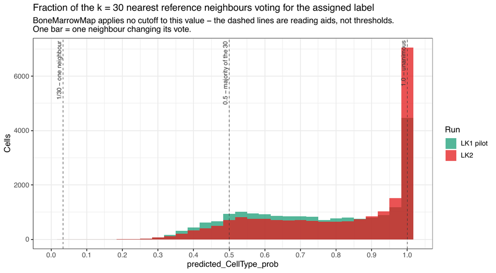

**`04_label_confidence_by_celltype.pdf`**

Median confidence by broad cell type. The low end is HSC MPP, LMPP, Early Lymphoid, Cycling Progenitor and Early GMP; the high end is Monocyte, cDC, pDC, Plasma Cell and Late Erythroid.

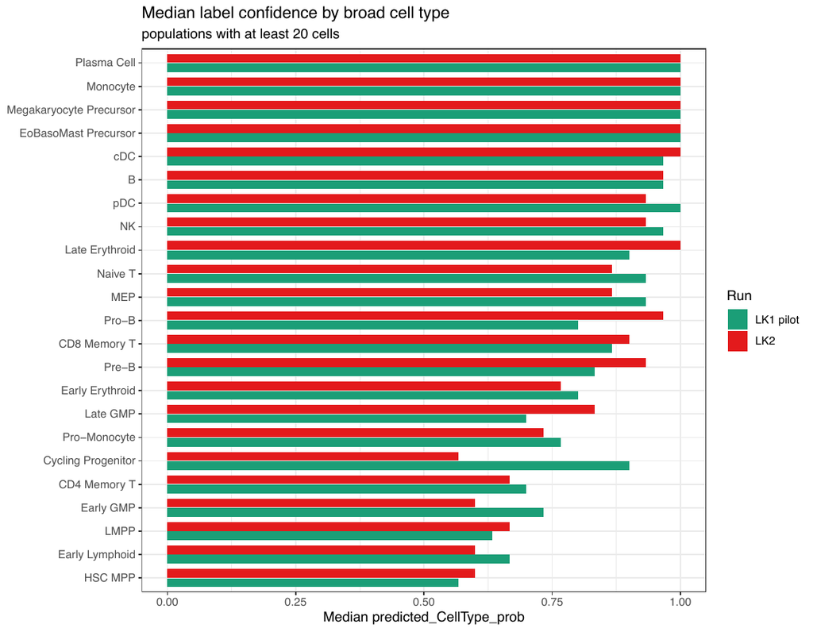

This is not a quality gradient. The populations with low confidence are the ones that are genuinely continuous - a cell part way along the HSC-to-LMPP axis should not get a unanimous vote, and the fact that it does not is the reference behaving correctly. It does mean that any analysis that treats HSC MPP as a discrete population is working with a soft boundary, which is worth remembering for the biotin split and for the surfaceome comparisons.

Ten least confident broad cell types (>= 20 cells)

| run | predicted_CellType_Broad | n | median_prob |
| --- | --- | --- | --- |
| LK1 pilot | HSC MPP | 4537 | 0.567 |
| LK2 | Cycling Progenitor | 119 | 0.567 |
| LK2 | Early GMP | 129 | 0.600 |
| LK2 | Early Lymphoid | 245 | 0.600 |
| LK2 | HSC MPP | 3857 | 0.600 |
| LK1 pilot | LMPP | 490 | 0.633 |
| LK1 pilot | Early Lymphoid | 394 | 0.667 |
| LK2 | CD4 Memory T | 473 | 0.667 |
| LK2 | LMPP | 767 | 0.667 |
| LK1 pilot | CD4 Memory T | 806 | 0.700 |

Ten most confident

| run | predicted_CellType_Broad | n | median_prob |
| --- | --- | --- | --- |
| LK1 pilot | EoBasoMast Precursor | 131 | 1 |
| LK1 pilot | Megakaryocyte Precursor | 40 | 1 |
| LK1 pilot | Monocyte | 1886 | 1 |
| LK1 pilot | Plasma Cell | 25 | 1 |
| LK1 pilot | pDC | 779 | 1 |
| LK2 | EoBasoMast Precursor | 261 | 1 |
| LK2 | Late Erythroid | 498 | 1 |
| LK2 | Megakaryocyte Precursor | 117 | 1 |
| LK2 | Monocyte | 2868 | 1 |
| LK2 | Plasma Cell | 39 | 1 |

# 5. What predict_CellTypes() actually does

initial_CellType versus predicted_CellType

| run | n | n_initial_NA | n_final_NA | n_QC_fail | final_NA_equals_QC_fail | percent_label_unchanged |
| --- | --- | --- | --- | --- | --- | --- |
| LK1 pilot | 21541 | 0 | 1713 | 1713 | TRUE | 100 |
| LK2 | 21800 | 0 | 1195 | 1195 | TRUE | 100 |

`initial_CellType` is never NA, `predicted_CellType` is NA for exactly the QC-failed cells, and wherever both are present they are identical for 100% of cells in both runs. So the second call is a gate, not a second opinion: it does not revise labels, it withholds them. That matters for anyone reading the object - `initial_CellType` is not a draft that got improved, it is the same answer without the QC applied.

# 6. Fine versus broad labels

Fine and broad label vocabularies

| run | n_fine_labels | n_broad_labels | fine_labels_in_broad_vocab | percent_cells_Other_if_keyed_on_fine | percent_cells_Other_if_keyed_on_broad |
| --- | --- | --- | --- | --- | --- |
| LK1 pilot | 53 | 24 | 9 | 84.3 | 0 |
| LK2 | 53 | 24 | 9 | 89.1 | 0 |

This is exactly what happened to the pilot’s `10_lineage_composition_by_sampleID.csv` and `12_specific_celltype_composition_by_sampleID.csv` - the latter has an all-NA cell type column on disk. Step 01 here is keyed on the broad column, and step 02 (the LK2 version that became the pipeline process) already was.

# 7. The mapping-error threshold

2.5 is the BoneMarrowMap default, and it is what the standalone scripts in steps 01 and 02 ran. **The pipeline does not use it.** `nextflow/bin/annotate.R` runs at `MAD_threshold = 4`; only `nextflow/bin/lib_early_qc_annotation.R` still has 2.5. So the figures in `results/seurat_annotated/` are at 2.5 and anything coming out of `results_nf/` is at 4, and the two are not interchangeable.

The score itself does not depend on the threshold - `calculate_MappingError()` stores `mapping_error_score` per cell and then calls Pass/Fail on `score < median(score) + MAD_threshold * mad(score)`, with median and MAD taken over the whole object. So the sweep below is computed directly from the stored score rather than by re-projecting. Recomputing the 2.5 call reproduces the stored `mapping_error_QC` for 100% of cells in both runs, which is what makes the other two columns trustworthy.

Rejection rate by run, at MAD_threshold 2.5, 3 and 4

| run | MAD_threshold | n_cells | n_rejected | percent_rejected |
| --- | --- | --- | --- | --- |
| LK1 pilot | 2.5 | 21541 | 1713 | 7.95 |
| LK1 pilot | 3.0 | 21541 | 1369 | 6.36 |
| LK1 pilot | 4.0 | 21541 | 842 | 3.91 |
| LK2 | 2.5 | 21800 | 1195 | 5.48 |
| LK2 | 3.0 | 21800 | 781 | 3.58 |
| LK2 | 4.0 | 21800 | 381 | 1.75 |

Rejection rate per sample, worst first (percent of that sample’s cells)

| run | sample | MAD 2.5 | MAD 3 | MAD 4 |
| --- | --- | --- | --- | --- |
| LK2 | APOP576-TP53 | 29.97 | 21.63 | 11.59 |
| LK1 pilot | HBDN501-AML-KMT2A | 11.13 | 8.43 | 5.17 |
| LK1 pilot | MOLM13 | 10.48 | 8.82 | 5.89 |
| LK1 pilot | HBDN392-AML-MDS | 6.87 | 5.39 | 3.04 |
| LK1 pilot | HBDN206-MNpCT | 4.75 | 3.68 | 2.06 |
| LK2 | normal-01 | 4.09 | 3.14 | 2.05 |
| LK2 | HBDN376-TP53 | 3.17 | 1.80 | 0.67 |
| LK2 | HBDN498-TP53 | 2.97 | 1.55 | 0.50 |

**`06_MAD_threshold_sweep.pdf`**

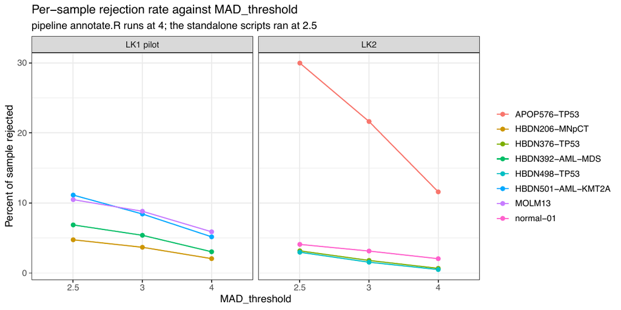

Going from 2.5 to 4 roughly halves the rejection rate - 7.95% to 3.91% in the pilot, 5.48% to 1.75% in LK2 - and 3 sits between them. Since section 3 shows the rejected cells are shallow, ribosome-poor and enriched for HTO negatives, the cells recovered by relaxing the threshold are mostly ones there is no good reason to keep. That argues for 2.5 rather than the 4 the pipeline currently runs, but it has not been changed, so the discrepancy stands and is worth resolving deliberately rather than by drift.

# 8. Projection output

The projected UMAP for both runs, coloured by `predicted_CellType_Broad` in the project palette. The versions in `results/seurat_annotated/` are coloured by the 53-level fine label in ggplot defaults and exist for one run at a time, which is why step 04a redraws them.

**`07_projected_umap_broad_both_runs.pdf`**

LK1 pilot and LK2 side by side. Same reference space, same palette, so the compositional difference between the two runs can be read directly off the map.

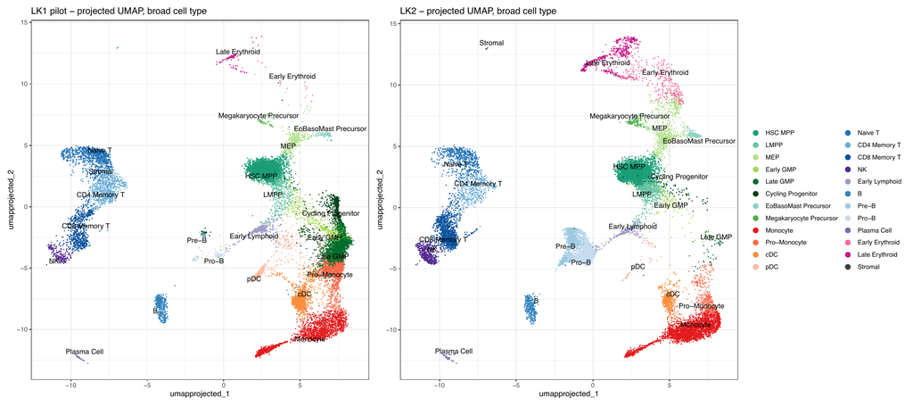

# 9. What was run

| Step | Script | What |
| --- | --- | --- |
| 00 | 00.celltype_palette.R | The bespoke broad-cell-type palette, lineage vocabulary and the check_palette() guard, defined once and sourced by steps 01-03. Run directly, it redraws the reference UMAPs. |
| 01 | 01.annotate_LK1_pilot.R | BoneMarrowMap projection of the LK1 pilot, MAD 2.5. |
| 02 | 02.annotate_LK2.R | The same projection on LK2. This is the version that became the pipeline’s 08_annotate process. |
| 03 | 03.check_unannotated_cells.R | Re-projects the LK2 pipeline checkpoint at MAD 4 and characterises the cells that still fail - QC covariates, donor, HTO class, native cluster, nearest annotated neighbour. |
| 04 | 04.annotation_benchmark_summary.R | Scores the annotation from the metadata tables alone: reject rates, rejected-cell profile, label confidence, initial-versus-final label, fine-versus-broad vocabulary, the MAD threshold sweep. |
| 04a | 04a.projected_umaps.R | Redraws the projected UMAP for both runs in the broad palette. Separate from step 04 because it is the only step that loads the ~450 MB projected objects. |
| 05 | 05.celltype_annotation_report.Rmd | This report. |

- `10a` had a `marker_map` / `plot_df` block sitting above the code that creates the objects it references, so it could only ever have been run interactively out of order. Removed.
- `10a.heatmap_cell_type_all.pdf` is 0 bytes on disk because scaling a zero-variance row gives NaN and `pheatmap` will not draw it. Fixed in both steps.
- the numbat export loops at the tails of `10a` and `8.annotate.R` belong to the CNV work, not to annotation. Dropped from both.
- every script carried its own copy of the palette, and the copies had drifted. All of them listed `GMP` - a label the reference never emits, since it splits that population into Early GMP and Late GMP - and none had an entry for `Stromal`, which the reference does emit. Because the plots do `factor(CellType_Broad, levels = names(celltype_cols))`, every stromal cell was being set to NA and dropped at the plotting step. That is why stromal cells looked unannotated: they were annotated, they were being discarded when drawn. The palette now lives in step 00 with `Stromal` in grey, and `check_palette()` raises a warning instead of silently dropping anything it does not recognise.

# 10. Data locations

Tools

| What | Where |
| --- | --- |
| BoneMarrowMap reference + uwot model | annotation/BoneMarrowMap_SymphonyReference.rds, annotation/BoneMarrowMap_uwot_model.uwot |
| Pilot input (CITE/DSB object) | results/cite_qc_then_dsb/260423_VH01624_453_222HWMYNX/LK1-GEX/seurat_demux_ADT_CLR_DSB_QC.rds |
| LK2 input (CITE/DSB object) | results/cite_seq_dsb/260528_VH01624_464_222K7VKNX/LK2-GEX/seurat_demux_ADT_CLR_DSB_QC.rds |
| LK2 pipeline checkpoint (step 03 input) | results_nf/260528_VH01624_464_222K7VKNX/rds/07_cite_qc/LK2-GEX/rds/seurat_demux_ADT_CLR_DSB_QC.rds |
| Pilot annotation outputs | results/seurat_annotated/260423_VH01624_453_222HWMYNX |
| LK2 annotation outputs | results/seurat_annotated/260528_VH01624_464_222K7VKNX |
| Unannotated-cell investigation | results/seurat_annotated/260528_VH01624_464_222K7VKNX/LK2-GEX_results_nf_unannotated_check |
| Benchmark tables and figures (step 04) | results/benchmarking/celltype_annotation |

| Tool | Version | Use |
| --- | --- | --- |
| BoneMarrowMap | 0.2.0 | Zeng et al. normal bone marrow Symphony reference and helpers |
| symphony | 0.1.2 | reference mapping |
| uwot | 0.2.4 | UMAP projection into reference coordinates |
| Seurat | 5.4.0 | object handling, DimPlot/FeaturePlot |
| class | 7.3.23 | kNN vote for the Unknown-cell identity assignment |
| pheatmap | 1.0.13 | composition heatmaps |

# 11. Caveats

- steps 01 and 02 are the collated, cleaned versions of the scripts that produced the original annotation, and were not re-executed - the projections they wrote in May and June are what everything here is computed from. Steps 00, 03, 04 and 04a were run fresh, which is what `Analysis finished` reflects. Step 03 reused its saved annotated object rather than re-projecting, so only its figures are new, not its numbers
- the pilot and LK2 numbers come from two different input objects and two different upstream CITE QC runs, so the difference in reject rate between runs is not a controlled comparison. The per-sample ordering within each run is, and so is the threshold sweep, which moves the same cells against the same score
- step 03 runs on the pipeline checkpoint at `MAD_threshold = 4`, not on the step 02 object at 2.5. Its 1.35% Unknown and step 02’s 5.48% Fail are therefore both correct and not directly comparable - the sweep in section 7 is the like-for-like version, since it recomputes both thresholds against the same cells
- the ADT/CITE marker projections that steps 01 and 02 also write are not shown here. The step 01 `ADT_ASSAY` argument still selects between `ADT_CLR` and `CITE_DSB` for them, and both were run; the figures are on disk under `projectionFigures/`
- APOP576-TP53’s 30% reject rate has not been chased down beyond noting it. It is the sample to look at first if that number matters
- pseudotime is inherited from the reference, not computed on our cells, so it should be read as “where in the normal trajectory does this cell project”, not as a trajectory of the leukaemia